# iDEP: Investigating Differentially Expressed Genes

## If this site has contributed to your work, please cite our article:

Ge, S.X., Son, E.W. & Yao, R. iDEP: an integrated web application for differential expression and pathway analysis of RNA-Seq data. BMC Bioinformatics 19, 534 (2018). https://doi.org/10.1186/s12859-018-2486-6

## Summary

Read Counts data were analyzed using iDEP v2.4.4. The data was first filtered to remove reads below 0.5 CPM in at least 1 sample. Then the data was transformed with EdgeR using a pseudocount of 4. Missing values were imputed using geneMedian.

After mapping, there are 32833 unique genes in 158 samples. Of the 24127 genes passed filter, 24127 were converted to Ensembl/STRING gene IDs in our database. The remaining 0 genes were kept in the data using original IDs.

Differential expression analysis was performed using DESeq2 with an FDR cutoff of 0.1 and a minimum fold-change threshold of 2. Standard Wald test was used and independent filtering was enabled.

## Selected Comparison: Radiation_Dose_cGy10-Radiation_Dose_cGy0

Up-regulated genes: 117

Down-regulated genes: 13

## Top Up-regulated Genes

```r
if (!is.null(params$up_genes_table) && nrow(params$up_genes_table) > 0) {
  kbl(params$up_genes_table, escape = FALSE) %>%
    kable_classic(full_width = FALSE, html_font = "Cambria")
} else {
  print("No up-regulated genes found for this comparison.")
}
```

| Symbol | Ensembl ID | log2 FC | Adj. P-value | Description |
| --- | --- | --- | --- | --- |
| AT1G09053 | AT1G09053 | 20.498 | 3.37e-33 | NcRNA |
| AT2G09785 | AT2G09785 | 13.675 | 8.26e-05 | NcRNA |
| AT1G68250 | AT1G68250 | 13.556 | 8.47e-17 | Uncharacterized protein |
| ATCG01000 | ATCG01000 | 7.703 | 6.28e-02 |  |
| AT4G11393 | AT4G11393 | 6.170 | 1.43e-08 | Defensin-like (DEFL) family protein |
| NAS2 | AT5G56080 | 4.336 | 1.28e-06 | Nicotianamine synthase 2 |
| ZIP9 | AT4G33020 | 3.926 | 1.03e-19 | ZIP metal ion transporter family |
| AT3G07255 | AT3G07255 | 3.646 | 1.26e-02 | Nuclear transport factor 2/RNA recognition motif protein |
| AT1G24996 | AT1G24996 | 3.092 | 6.97e-03 | Uncharacterized protein |
| MYB101 | AT2G32460 | 3.090 | 6.34e-03 | Myb domain protein 101 |
| AT1G13480 | AT1G13480 | 2.981 | 2.51e-05 |  |
| AT3G61390 | AT3G61390 | 2.603 | 6.55e-06 | RING/U-box superfamily protein |
| AT5G57510 | AT5G57510 | 2.586 | 8.07e-04 | Cotton fiber protein |
| PCK2 | AT5G65690 | 2.440 | 6.24e-04 | Phosphoenolpyruvate carboxykinase 2 |
| AT3G51360 | AT3G51360 | 2.431 | 6.31e-02 | Eukaryotic aspartyl protease family protein |
| AT4G37850 | AT4G37850 | 2.409 | 8.00e-02 | Basic helix-loop-helix (bHLH) DNA-binding superfamily protein |
| MMP | AT1G70170 | 2.393 | 1.15e-05 | Matrix metalloproteinase |
| AT5G42510 | AT5G42510 | 2.375 | 1.45e-02 | Disease resistance-responsive (dirigent-like protein) family protein |
| AT3G09950 | AT3G09950 | 2.369 | 1.34e-02 | Uncharacterized protein |
| AT5G37210 | AT5G37210 | 2.344 | 7.41e-02 | Cysteine/Histidine-rich C1 domain family protein |
| EXO70H1 | AT3G55150 | 2.324 | 4.32e-04 | Exocyst subunit exo70 family protein H1 |
| AT1G76470 | AT1G76470 | 2.294 | 1.16e-03 | NAD(P)-binding Rossmann-fold superfamily protein |
| AT1G71520 | AT1G71520 | 2.192 | 7.03e-03 | Integrase-type DNA-binding superfamily protein |
| AT2G42060 | AT2G42060 | 2.148 | 8.44e-02 | Cysteine/Histidine-rich C1 domain family protein |
| MSRB7 | AT4G21830 | 2.118 | 4.35e-05 | Methionine sulfoxide reductase B7 |
| AT3G53600 | AT3G53600 | 2.079 | 1.66e-02 | C2H2-type zinc finger family protein |
| AT1G51820 | AT1G51820 | 2.065 | 2.00e-04 | Leucine-rich repeat protein kinase family protein |
| AT4G27654 | AT4G27654 | 2.062 | 8.97e-02 | Uncharacterized protein |
| AT1G04537 | AT1G04537 | 2.052 | 3.34e-02 | NcRNA |
| ATPC2 | AT1G15700 | 2.043 | 5.41e-02 | ATPase, F1 complex, gamma subunit protein |
| AT1G58223 | AT1G58223 | 2.014 | 9.99e-02 | Uncharacterized protein |
| BGLU22 | AT1G66280 | 1.922 | 4.24e-05 | Glycosyl hydrolase superfamily protein |
| AT1G51850 | AT1G51850 | 1.917 | 2.02e-12 | Leucine-rich repeat protein kinase family protein |
| AT3G02840 | AT3G02840 | 1.914 | 4.19e-02 | ARM repeat superfamily protein |
| AT1G07160 | AT1G07160 | 1.892 | 1.54e-02 | Protein phosphatase 2C family protein |
| AT1G62420 | AT1G62420 | 1.888 | 7.89e-02 | DUF506 family protein (DUF506) |
| AT2G47935 | AT2G47935 | 1.885 | 1.75e-02 | Uncharacterized protein |
| AT2G43620 | AT2G43620 | 1.875 | 6.55e-05 | Chitinase family protein |
| AT5G49690 | AT5G49690 | 1.861 | 1.60e-03 | UDP-Glycosyltransferase superfamily protein |
| AT1G13520 | AT1G13520 | 1.805 | 2.98e-02 |  |
| MAPKKK19 | AT5G67080 | 1.740 | 8.34e-03 | Mitogen-activated protein kinase kinase kinase 19 |
| DREB2C | AT2G40340 | 1.713 | 2.73e-03 | Integrase-type DNA-binding superfamily protein |
| AT4G33980 | AT4G33980 | 1.693 | 2.07e-02 | Uncharacterized protein |
| UGT76B1 | AT3G11340 | 1.689 | 6.55e-05 | UDP-Glycosyltransferase superfamily protein |
| IOS1 | AT1G51800 | 1.668 | 1.95e-08 | Leucine-rich repeat protein kinase family protein |
| XTH18 | AT4G30280 | 1.661 | 4.15e-07 | Xyloglucan endotransglucosylase/hydrolase 18 |
| AT5G36907 | AT5G36907 | 1.659 | 1.65e-02 | Uncharacterized protein |
| OCT1 | AT1G73220 | 1.644 | 9.04e-02 | Organic cation/carnitine transporter1 |
| PDE337 | AT1G68450 | 1.641 | 2.07e-02 | VQ motif-containing protein |
| AT3G46080 | AT3G46080 | 1.636 | 3.78e-02 | C2H2-type zinc finger family protein |

## Top Down-regulated Genes

```r
if (!is.null(params$down_genes_table) && nrow(params$down_genes_table) > 0) {
  kbl(params$down_genes_table, escape = FALSE) %>%
    kable_classic(full_width = FALSE, html_font = "Cambria")
} else {
  print("No down-regulated genes found for this comparison.")
}
```

| Symbol | Ensembl ID | log2 FC | Adj. P-value | Description |
| --- | --- | --- | --- | --- |
| AT1G05562 | AT1G05562 | -18.102 | 3.40e-04 | NcRNA |
| LpxC5 | AT1G25210 | -17.786 | 4.63e-33 | UDP-3-O-acyl N-acetylglycosamine deacetylase family protein |
| CRU3 | AT4G28520 | -8.282 | 4.03e-04 | Cruciferin 3 |
| AT1G06475 | AT1G06475 | -3.405 | 8.91e-07 | Uncharacterized protein |
| AT2G08060 | AT2G08060 | -3.366 | 2.26e-06 | NcRNA |
| AT1G43020 | AT1G43020 | -2.419 | 3.70e-02 | Electron protein, putative (Protein of unknown function, DUF547) |
| AT3G23180 | AT3G23180 | -1.971 | 9.13e-02 | HR-like lesion-inducing protein-like protein |
| AT1G55152 | AT1G55152 | -1.826 | 2.04e-02 | Uncharacterized protein |
| bHLH38 | AT3G56970 | -1.526 | 6.01e-02 | Basic helix-loop-helix (bHLH) DNA-binding superfamily protein |
| HAP2 | AT4G11720 | -1.470 | 8.00e-02 | Hapless 2 |
| bHLH39 | AT3G56980 | -1.245 | 6.78e-02 | Basic helix-loop-helix (bHLH) DNA-binding superfamily protein |
| AT3G59370 | AT3G59370 | -1.070 | 9.24e-02 | Vacuolar calcium-binding protein-like protein |
| AT3G16670 | AT3G16670 | -1.030 | 8.16e-04 | Pollen Ole e 1 allergen and extensin family protein |

## DEG Heatmap

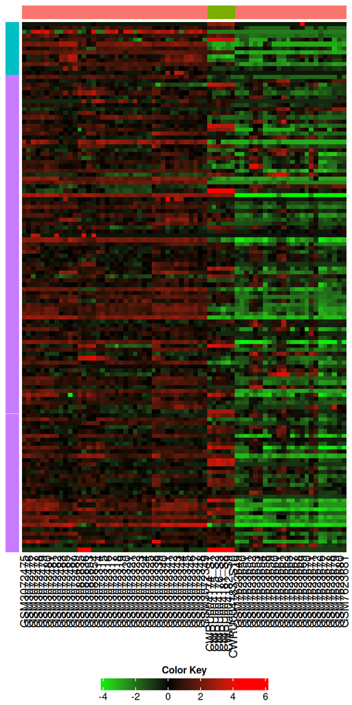

```r
if (!is.null(params$heat_data) && !is.null(params$heat_bar)) {
  heat_colors <- unlist(strsplit(params$heatmap_color_select, "-"))

  deg_heatmap(
    df = params$heat_data,
    bar = params$heat_bar,
    heatmap_color_select = heat_colors,
    cluster_rows = FALSE
  )
}
```

## Volcano Plot

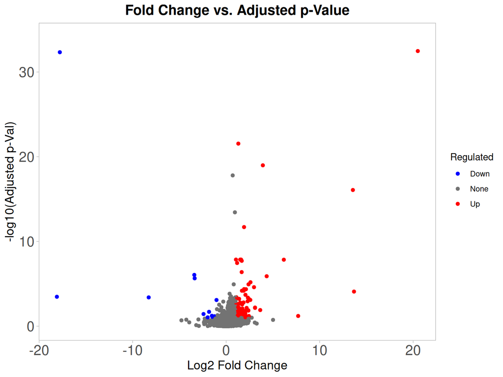

```r
if (!is.null(params$vol_data) && !is.null(params$vol_data$data)) {
  p <- plot_volcano(
    data = params$vol_data$data,
    plot_colors = params$plot_colors,
    anotate_genes = params$gene_labels_volcano
  )
  p <- refine_ggplot2(
    p = p,
    gridline = params$plot_grid_lines,
    ggplot2_theme = params$ggplot2_theme
  )
  print(p)
}
```